# FINAL ASSESSMENT

### IBM SkillsBuild Europe Delivery - Data Analytics

# Lenara Sitshayeva

### Data Analytics of Airbnb Data:

#### Tasks:

- Data Cleaning.
- Data Transformation
- Data Visualization.

#### Overview of Airbnb Data:

People's main criteria when visiting new places are reasonable accommodation and food. Airbnb (Air-Bed-Breakfast) is an online marketplace created to meet this need of people by renting out their homes for a short term. They offer this facility at a relatively lower price than hotels. Further people worldwide prefer the homely and economical service offered by them. They offer services across various geographical locations

#### Dataset Source

The dataset for this assessment the following link: http://data.insideairbnb.com/united-kingdom/england/london/2022-09-10/data/listings.csv.gz

This dataset contains information for London such as the neighborhood offering these services, room type, price,avaliabilty, reviews. This analysis will help airbnb in improving its services.

## Task 1: Data Loading

1. Read the csv file and load it into a pandas dataframe.
2. Display the first five rows of your dataframe.
3. Display the data types of the columns.

```python
## Import pandas
import pandas as pd
pd.options.display.max_columns = None
pd.options.display.max_rows = None
```

```python
## Read the csv file london_data.csv
df = pd.read_csv("london_data.csv")
```

```python
## Display the first 5 rows
df.head(5)
```

[output not shown]

```python
## Display the data types
df.info()
```

[output not shown]

## Task 2a: Data Cleaning

1. Drop some of the unwanted columns.
2. State the reason for not including these columns for this Data Analytics.

### For this Data Analysis there are some unwanted columns, that we shoud drop from dataset.

These columns won't be useful for this Data Analysis:

- listing_url, scrape_id, last_scraped, source,
- picture_url, host_url, host_name, host_location,
- host_thumbnail_url, host_picture_url,
- latitude, longitude, calendar_updated,
- availability_30, availability_60, availability_90,
- calendar_last_scraped, license.

These columns don't contain information that may affect the insights we plan to extract from this dataset.

```python
df.drop(["listing_url", "scrape_id", "last_scraped", "source"], axis="columns", inplace = True)
```

```python
df.drop(["picture_url", "host_url", "host_name", "host_location"], axis="columns", inplace = True)
```

```python
df.drop(["host_thumbnail_url", "host_picture_url"], axis="columns", inplace = True)
```

```python
df.drop(["latitude", "longitude", "calendar_updated"], axis="columns", inplace = True)
```

```python
df.drop(["availability_30", "availability_60", "availability_90"], axis="columns", inplace = True)
```

```python
df.drop(["calendar_last_scraped", "license"], axis="columns", inplace = True)
```

```python
## Now we can check presence dropped columns in dataset.
## We got error message, so dataset no longer contains these columns
df["listing_url", "license"]
```

[output not shown]

## Task 2b: Data Cleaning

- Check for missing values in the dataframe and display the count in ascending order.
- If the values are missing, impute the values as per the datatype of the columns.
- Check whether there are any duplicate values in the dataframe and, if present, remove them.
- Display the total number of records in the dataframe before and after removing the duplicates.

### Strategies for dealing with missing data.

1. If the column has less than 5% of missing values, drop the rows where these values are missing.
2. For the columns where the missing values are between 5< THE COLUMN <60, then fix these values.
3. If the column has more than 60% of its values missing, drop the column.

### Requirements:

- Minimum Threshold
- Maximum Threshold

### Rules of Thumb for Imputing Missing Values:

- For categorical columns: the mode
- For text columns: "Unknown"
- For integers columns: the median or the mean
- For floats columns: the median or the mean

```python
##Check for missing values in the dataframe
df.isna().tail()
```

|  | id | name | description | neighborhood_overview | host_id | host_since | host_about | host_response_time | host_response_rate | host_acceptance_rate | host_is_superhost | host_neighbourhood | host_listings_count | host_total_listings_count | host_verifications | host_has_profile_pic | host_identity_verified | neighbourhood | neighbourhood_cleansed | neighbourhood_group_cleansed | property_type | room_type | accommodates | bathrooms | bathrooms_text | bedrooms | beds | amenities | price | … |
| --- | --- | --- | --- | --- | --- | --- | --- | --- | --- | --- | --- | --- | --- | --- | --- | --- | --- | --- | --- | --- | --- | --- | --- | --- | --- | --- | --- | --- | --- | --- |
| 69346 | False | False | False | False | False | False | False | False | False | False | False | False | False | False | False | False | False | False | False | True | False | False | False | True | False | False | False | False | False | … |
| 69347 | False | False | False | False | False | False | False | False | False | False | False | True | False | False | False | False | False | False | False | True | False | False | False | True | False | False | False | False | False | … |
| 69348 | False | False | False | False | False | False | False | False | False | False | False | True | False | False | False | False | False | False | False | True | False | False | False | True | False | False | False | False | False | … |
| 69349 | False | False | False | False | False | False | False | True | True | False | False | True | False | False | False | False | False | False | False | True | False | False | False | True | False | False | False | False | False | … |
| 69350 | False | False | False | False | False | False | False | True | True | True | False | False | False | False | False | False | False | False | False | True | False | False | False | True | False | False | False | False | False | … |

```python
## Check for missing values in the dataframe and display the count in ascending order.
df.isna().sum().sort_values(ascending = True)
```

```
id                                                  0
room_type                                           0
accommodates                                        0
amenities                                           0
calculated_host_listings_count_shared_rooms         0
minimum_nights                                      0
maximum_nights                                      0
has_availability                                    0
availability_365                                    0
number_of_reviews                                   0
number_of_reviews_ltm                               0
number_of_reviews_l30d                              0
instant_bookable                                    0
calculated_host_listings_count                      0
calculated_host_listings_count_entire_homes         0
calculated_host_listings_count_private_rooms        0
property_type                                       0
neighbourhood_cleansed                              0
price                                               0
host_id                                             0
host_verifications                                  0
minimum_maximum_nights                              3
maximum_nights_avg_ntm                              3
minimum_nights_avg_ntm                              3
maximum_maximum_nights                              3
maximum_minimum_nights                              3
minimum_minimum_nights                              3
host_listings_count                                 5
host_since                                          5
host_has_profile_pic                                5
host_identity_verified                              5
host_total_listings_count                           5
host_is_superhost                                  19
name                                               21
bathrooms_text                                    131
beds                                             1200
description                                      1519
bedrooms                                         3429
first_review                                    16780
review_scores_rating                            16780
last_review                                     16780
reviews_per_month                               16780
review_scores_cleanliness                       17789
review_scores_accuracy                          17802
review_scores_communication                     17803
review_scores_location                          17834
review_scores_checkin                           17836
review_scores_value                             17837
host_acceptance_rate                            24261
host_neighbourhood                              25754
host_response_time                              26521
host_response_rate                              26521
neighbourhood                                   29386
neighborhood_overview                           29387
host_about                                      32405
bathrooms                                       69351
neighbourhood_group_cleansed                    69351
dtype: int64
```

```python
## If the values are missing, impute the values as per the datatype of the columns
df["host_about"]. fillna("Unknown", inplace = True)
# df.fillna(value = {"host_about": "Unknown"})
df["host_about"]. tail(20)
```

```
69331    I am English - for the last 1000 yrs anyhow - ...
69332                                              Unknown
69333                                              Unknown
69334    Simon and Sheba Cassini are infamous as 2 of L...
69335                                              Unknown
69336    Born and bred from London, but I've moved into...
69337                                              Unknown
69338    Picture: I am on the right\n\nI am an Aussie E...
69339    Born and bred from London, but I've moved into...
69340    Born and bred from London, but I've moved into...
69341    Hoping to make more time for travel and weeken...
69342    Hello I'm an Anglo Indian lady and I love to t...
69343    Hello there,\r\n\r\nMy name is Ayoub I'm origi...
69344    We are two artists, Thomas & Angel who are res...
69345                                              Unknown
69346    Hi I'm Kurt. I'm originally from Barbados and ...
69347    We are a professional couple, American and Bri...
69348    I'm a marketing consultant and chef from Manch...
69349    Father of 4 children and 3 grandchildren. Love...
69350    Hi there!\n\nWe're GuestReady, a professional ...
Name: host_about, dtype: object
```

```python
df["review_scores_rating"].tail(20)
```

```
69331    4.61
69332    5.00
69333    5.00
69334     NaN
69335    4.90
69336    5.00
69337    4.89
69338    5.00
69339    4.56
69340    4.67
69341    4.92
69342     NaN
69343     NaN
69344    4.95
69345    4.16
69346    4.90
69347    4.90
69348    5.00
69349    5.00
69350    4.88
Name: review_scores_rating, dtype: float64
```

```python
## Calculate median value for review_scores_rating
median_reviews_value = df["review_scores_rating"].median()
median_reviews_value
```

```
4.82
```

```python
## there are NaN values in review_scores_rating column
df["review_scores_rating"].tail(10)
```

```
69341    4.92
69342     NaN
69343     NaN
69344    4.95
69345    4.16
69346    4.90
69347    4.90
69348    5.00
69349    5.00
69350    4.88
Name: review_scores_rating, dtype: float64
```

```python
## impute missing values by median value
df.fillna(value = {"review_scores_rating": median_reviews_value}, inplace = True)
df["review_scores_rating"].tail(10)
```

```
69341    4.92
69342    4.82
69343    4.82
69344    4.95
69345    4.16
69346    4.90
69347    4.90
69348    5.00
69349    5.00
69350    4.88
Name: review_scores_rating, dtype: float64
```

```python
##Display the total number of records in the dataframe before removing the duplicates.
len(df)
```

```
69351
```

```python
## Check whether there are any duplicate values in the dataframe and if present remove them.
df.duplicated().tail()
```

```
69346    False
69347    False
69348    False
69349    False
69350    False
dtype: bool
```

```python
## Display the total number of duplicate values in the dataframe after removing the duplicates.
df.duplicated().sum()
```

```
0
```

```python
## Display the total number of records in the dataframe after removing the duplicates.
len(df)
```

```
69351
```

## Task 3: Data Transformation

- Rename the column `availability 365` to `days_booked`
- Remove the dollar sign and comma from the columns `price'.
- If necessary, convert these two columns to the appropriate data type.

```python
## Rename the column availability 365 to days_booked
df.rename(mapper={"availability_365":"days_booked"}, axis = "columns", inplace = True)
```

```python
## Check renamed column
df.tail(2)
```

|  | id | name | description | neighborhood_overview | host_id | host_since | host_about | host_response_time | host_response_rate | host_acceptance_rate | host_is_superhost | host_neighbourhood | host_listings_count | host_total_listings_count | host_verifications | host_has_profile_pic | host_identity_verified | neighbourhood | neighbourhood_cleansed | neighbourhood_group_cleansed | property_type | room_type | accommodates | bathrooms | bathrooms_text | bedrooms | beds | amenities | price | … |
| --- | --- | --- | --- | --- | --- | --- | --- | --- | --- | --- | --- | --- | --- | --- | --- | --- | --- | --- | --- | --- | --- | --- | --- | --- | --- | --- | --- | --- | --- | --- |
| 69349 | 49698549 | Waterfront Hampton Stay | This luxury waterfront home is located on a ti... | Hampton is located on the outskirts of London ... | 34213667 | 2015-05-25 | Father of 4 children and 3 grandchildren. Love... | NaN | NaN | 80% | f | NaN | 1.0 | 1.0 | ['phone'] | t | t | Greater London, England, United Kingdom | Richmond upon Thames | NaN | Entire bungalow | Entire home/apt | 2 | NaN | 1 bath | 1.0 | 1.0 | ["Extra pillows and blankets", "Oven", "Fire e... | $250.00 | … |
| 69350 | 554172169432589107 | GuestReady Gorgeous Bright 2 Br Apartment in | Boasting a lovely balcony & plenty of sunshine... | Set in a lovely area, Liddiard House is only a... | 402191311 | 2021-05-18 | Hi there!\n\nWe're GuestReady, a professional ... | NaN | NaN | NaN | f | Bastille | 953.0 | 1834.0 | ['email', 'phone'] | t | f | Greater London, England, United Kingdom | Greenwich | NaN | Entire rental unit | Entire home/apt | 4 | NaN | 1 bath | 2.0 | 2.0 | ["Essentials", "Wifi", "Hot water", "Washer", ... | $134.00 | … |

```python
## Remove the dollar sign and comma from the columns. If necessary, convert these two columns to the appropriate data type.
df["price"] = df["price"].str.replace("$","").str.replace(",", "").astype(float)
```

### Task 4: Exploratory Data Analysis

- List the count of various room types avaliable in the dataset.
- Which room type has the most strict cancellation policy?
- List the average price per neighborhood group, and highlight the most expensive neighborhood to rent from.

```python
## Display dataset
df.tail()
```

|  | id | name | description | neighborhood_overview | host_id | host_since | host_about | host_response_time | host_response_rate | host_acceptance_rate | host_is_superhost | host_neighbourhood | host_listings_count | host_total_listings_count | host_verifications | host_has_profile_pic | host_identity_verified | neighbourhood | neighbourhood_cleansed | neighbourhood_group_cleansed | property_type | room_type | accommodates | bathrooms | bathrooms_text | bedrooms | beds | amenities | price | … |
| --- | --- | --- | --- | --- | --- | --- | --- | --- | --- | --- | --- | --- | --- | --- | --- | --- | --- | --- | --- | --- | --- | --- | --- | --- | --- | --- | --- | --- | --- | --- |
| 69346 | 9671724 | Cozy room in Greenwich, river view | Single room available in a new three bedroom, ... | The following attractions can be found in Gree... | 49977905 | 2015-11-27 | Hi I'm Kurt. I'm originally from Barbados and ... | within a day | 100% | 0% | f | Greenwich | 15.0 | 15.0 | ['email', 'phone'] | t | t | London, Greater London, United Kingdom | Greenwich | NaN | Private room in rental unit | Private room | 1 | NaN | 1 shared bath | 1.0 | 1.0 | ["Oven", "Hair dryer", "Hangers", "Dishes and ... | 55.0 | … |
| 69347 | 20277958 | River view Tate Modern | Best location in London, overlooking Thames Ri... | Best location in London, overlooking Thames Ri... | 1132775 | 2011-09-09 | We are a professional couple, American and Bri... | within a few hours | 100% | 86% | t | NaN | 1.0 | 1.0 | ['email', 'phone'] | t | t | Greater London, England, United Kingdom | Southwark | NaN | Entire condo | Entire home/apt | 5 | NaN | 1 bath | 1.0 | 3.0 | ["First aid kit", "Oven", "Fire extinguisher",... | 201.0 | … |
| 69348 | 20512703 | Luxury 4 bed house, 100m to river and palace | Forget your worries in this spacious and seren... | Quiet, community suburb of London. River comes... | 1706966 | 2012-02-06 | I'm a marketing consultant and chef from Manch... | within a day | 83% | 70% | f | NaN | 1.0 | 1.0 | ['email', 'phone', 'work_email'] | t | t | Surrey, England, United Kingdom | Richmond upon Thames | NaN | Entire home | Entire home/apt | 6 | NaN | 2 baths | 4.0 | 5.0 | ["Extra pillows and blankets", "First aid kit"... | 246.0 | … |
| 69349 | 49698549 | Waterfront Hampton Stay | This luxury waterfront home is located on a ti... | Hampton is located on the outskirts of London ... | 34213667 | 2015-05-25 | Father of 4 children and 3 grandchildren. Love... | NaN | NaN | 80% | f | NaN | 1.0 | 1.0 | ['phone'] | t | t | Greater London, England, United Kingdom | Richmond upon Thames | NaN | Entire bungalow | Entire home/apt | 2 | NaN | 1 bath | 1.0 | 1.0 | ["Extra pillows and blankets", "Oven", "Fire e... | 250.0 | … |
| 69350 | 554172169432589107 | GuestReady Gorgeous Bright 2 Br Apartment in | Boasting a lovely balcony & plenty of sunshine... | Set in a lovely area, Liddiard House is only a... | 402191311 | 2021-05-18 | Hi there!\n\nWe're GuestReady, a professional ... | NaN | NaN | NaN | f | Bastille | 953.0 | 1834.0 | ['email', 'phone'] | t | f | Greater London, England, United Kingdom | Greenwich | NaN | Entire rental unit | Entire home/apt | 4 | NaN | 1 bath | 2.0 | 2.0 | ["Essentials", "Wifi", "Hot water", "Washer", ... | 134.0 | … |

```python
## List the count of various room types avaliable
df.room_type.value_counts()
```

```
Entire home/apt    41224
Private room       27479
Shared room          404
Hotel room           244
Name: room_type, dtype: int64
```

```python
## List the count of various property types avaliable
df.property_type.value_counts()
```

```
Entire rental unit                    22780
Private room in rental unit           12133
Entire condo                           8676
Private room in home                   8500
Entire home                            5379
Private room in condo                  2753
Entire serviced apartment              1829
Private room in townhouse              1410
Entire townhouse                       1121
Private room in bed and breakfast       542
Room in hotel                           481
Entire loft                             429
Room in boutique hotel                  360
Private room in guesthouse              210
Entire guest suite                      196
Private room in loft                    186
Entire guesthouse                       178
Private room in guest suite             176
Shared room in rental unit              157
Room in aparthotel                      139
Private room in casa particular         134
Private room in serviced apartment      126
Private room in hostel                  122
Entire vacation home                    119
Room in serviced apartment              114
Private room                             94
Shared room in home                      84
Private room in bungalow                 80
Shared room in hostel                    77
Entire cottage                           70
Entire bungalow                          62
Boat                                     53
Private room in vacation home            48
Entire villa                             47
Entire place                             44
Tiny home                                43
Room in bed and breakfast                36
Shared room in condo                     32
Private room in cottage                  30
Room in hostel                           29
```

[output cut: 46 more lines]

```
Treehouse                                 1
Riad                                      1
Shared room in vacation home              1
Minsu                                     1
Private room in tipi                      1
Tent                                      1
Private room in parking space             1
Dome                                      1
Private room in shepherd's hut            1
Shared room in earthen home               1
Shared room in villa                      1
Yurt                                      1
Shared room in bus                        1
Bus                                       1
Name: property_type, dtype: int64
```

```python
## List top 10 property types
df.groupby("property_type")["id"].count().sort_values(ascending = False).head(10)
```

```
property_type
Entire rental unit                   22780
Private room in rental unit          12133
Entire condo                          8676
Private room in home                  8500
Entire home                           5379
Private room in condo                 2753
Entire serviced apartment             1829
Private room in townhouse             1410
Entire townhouse                      1121
Private room in bed and breakfast      542
Name: id, dtype: int64
```

```python
## Which room type adheres to more strict cancellation policy
## Dataset doesn't contain column cancellation_policy, but we can use column host_response_time
df.pivot_table(
    index = "room_type",
    columns = "host_response_time",
    values = "id",
    aggfunc = "count"
)
```

| host_response_time room_type | a few days or more | within a day | within a few hours | within an hour |
| --- | --- | --- | --- | --- |
| Entire home/apt | 804 | 3591 | 5866 | 16893 |
| Hotel room | 2 | 25 | 11 | 170 |
| Private room | 755 | 1706 | 3184 | 9601 |
| Shared room | 22 | 15 | 22 | 163 |

```python
df.pivot_table(
    index = "instant_bookable",
    columns = "host_response_time",
    values = "id",
    aggfunc = "count"
)
```

| host_response_time instant_bookable | a few days or more | within a day | within a few hours | within an hour |
| --- | --- | --- | --- | --- |
| f | 1156 | 4724 | 7469 | 12390 |
| t | 427 | 613 | 1614 | 14437 |

```python
## Display column price in dataset after changing type
df.price.tail()
```

```
69346     55.0
69347    201.0
69348    246.0
69349    250.0
69350    134.0
Name: price, dtype: float64
```

```python
## List average price for neighborhood in descending order
df.groupby("neighbourhood_cleansed")["price"].mean().sort_values(ascending = False)
```

```
neighbourhood_cleansed
Kensington and Chelsea    302.882047
Westminster               296.950148
City of London            269.063679
Hammersmith and Fulham    211.041389
Brent                     206.438104
Kingston upon Thames      198.673235
Southwark                 195.298387
Camden                    193.725303
Wandsworth                176.366254
Richmond upon Thames      174.631769
Newham                    170.124257
Hounslow                  160.188840
Barnet                    155.468653
Islington                 148.832755
Merton                    147.291741
Haringey                  143.168072
Greenwich                 132.355350
Lambeth                   130.569508
Tower Hamlets             126.876139
Hackney                   125.466331
Havering                  115.191489
Ealing                    114.104314
Bromley                   112.742424
Redbridge                 110.484305
Harrow                     99.702703
Lewisham                   99.341414
Hillingdon                 98.271709
Barking and Dagenham       96.411085
Enfield                    96.119935
Waltham Forest             95.408472
Bexley                     89.686131
Sutton                     84.674825
Croydon                    82.561914
Name: price, dtype: float64
```

```python
## List Top 10 the most expensive neighborhood for rentals
most_expensive = df.groupby("neighbourhood_cleansed")["price"].mean().sort_values(ascending = False).head(10)
most_expensive
```

```
neighbourhood_cleansed
Kensington and Chelsea    302.882047
Westminster               296.950148
City of London            269.063679
Hammersmith and Fulham    211.041389
Brent                     206.438104
Kingston upon Thames      198.673235
Southwark                 195.298387
Camden                    193.725303
Wandsworth                176.366254
Richmond upon Thames      174.631769
Name: price, dtype: float64
```

```python
## List the average prices by neighborhood group  for rentals
avg_neighbourhood_price = df.groupby("neighbourhood_cleansed")["price"].mean().sort_values(ascending=False)
avg_neighbourhood_price
```

```
neighbourhood_cleansed
Kensington and Chelsea    302.882047
Westminster               296.950148
City of London            269.063679
Hammersmith and Fulham    211.041389
Brent                     206.438104
Kingston upon Thames      198.673235
Southwark                 195.298387
Camden                    193.725303
Wandsworth                176.366254
Richmond upon Thames      174.631769
Newham                    170.124257
Hounslow                  160.188840
Barnet                    155.468653
Islington                 148.832755
Merton                    147.291741
Haringey                  143.168072
Greenwich                 132.355350
Lambeth                   130.569508
Tower Hamlets             126.876139
Hackney                   125.466331
Havering                  115.191489
Ealing                    114.104314
Bromley                   112.742424
Redbridge                 110.484305
Harrow                     99.702703
Lewisham                   99.341414
Hillingdon                 98.271709
Barking and Dagenham       96.411085
Enfield                    96.119935
Waltham Forest             95.408472
Bexley                     89.686131
Sutton                     84.674825
Croydon                    82.561914
Name: price, dtype: float64
```

## Task 5a: Data Visualization

- Create a horizontal bar chart to display the top 10 most expensive neighborhoods in the dataset.
- Create another chart with the 10 cheapest neighborhoods in the dataset.
- Create a box and whisker chart that showcases the price distribution of all listings split by room type.

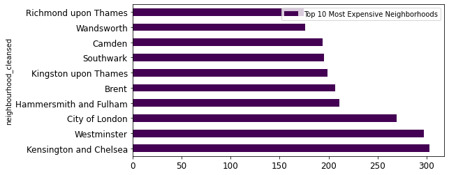

```python
## Create a horizontal bar chart to display the top 10 most expensive neighborhoods in the dataset.
most_expensive.head(10).plot(kind="barh", figsize = (8,4), fontsize = 12, colormap="viridis", label = "Top 10 Most Expensive Neighborhoods", legend=True)
```

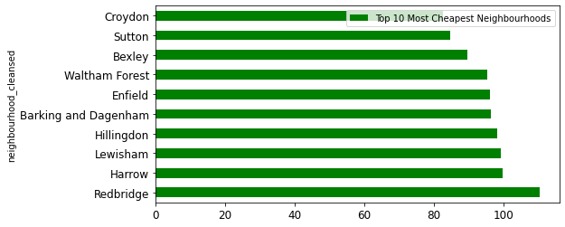

```python
## Create bar chart with the 10 cheapest neighborhoods in the dataset.
avg_neighbourhood_price.tail(10).plot(kind="barh", figsize = (8,6), fontsize = 12, colormap="ocean", label = "Top 10 Most Cheapest Neighbourhoods", legend=True)
```

```python
## Create price mask
price_mask = (df.price < 300)
```

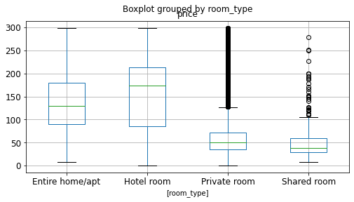

```python
## Create a box chart that show the price distribution of all listings split by room type.
df.loc[price_mask,["price", "room_type"]].boxplot(by="room_type", figsize=(8, 6), rot=0, fontsize=12)
```

Based on boxplot we can draw the conclusion that highest prices have listings for hotel_room and Entire home/apt.

## Task 5b: Data Visualization

- Create a scatter plot to illustrate the relationship between
- the number_of_reviews and the room price and write down the kind of correlation, if any, that you see.
- Create a line graph to show the total number of listings for each "Construction year".

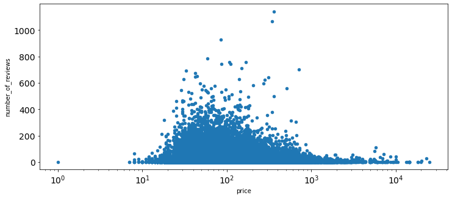

```python
## Create a scatter plot to illustrate the relationship between the number_of_reviews and the room price
df.plot.scatter(x = 'price', y = 'number_of_reviews', logx = True, figsize = (12,5), fontsize = 14);
```

```python
## Check column host_since
df["host_since"].head()
```

```
0    2009-11-16
1    2009-12-05
2    2011-12-07
3    2010-10-17
4    2010-01-04
Name: host_since, dtype: object
```

```python
## Convert datatype column host_since to datetime
pd.to_datetime(df["host_since"]).head()
```

```
0   2009-11-16
1   2009-12-05
2   2011-12-07
3   2010-10-17
4   2010-01-04
Name: host_since, dtype: datetime64[ns]
```

```python
## Extract year
pd.to_datetime(df["host_since"]).head().dt.year
```

```
0    2009
1    2009
2    2011
3    2010
4    2010
Name: host_since, dtype: int64
```

```python
## Create column year
df["year"] = pd.to_datetime(df["host_since"]).dt.year
```

```python
## Create a line graph to show the total number of listings for each "Construction year".
df.groupby("year")["id"].count().plot(linestyle='--', marker='o', color='b', label='Total number of listings', legend=True, figsize = (12,7), fontsize = 12)
```

[output not shown]